# Análise Exploratória do Conjunto de Dados SiP

## O que são os dados

Conjunto de dados com informações de 12299 tarefas realizadas por 22 desenvolvedores em 20 códigos de projeto utilizando metodologia ágil.

## Entendendo os dados

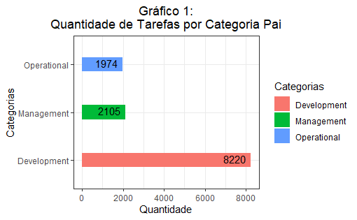

Ao perceber que os dados são divididos por categorias, é importante mensurar a quantidade de dados para cada uma delas. Sendo assim, é constatado através do Gráfico 1 os seguintes números: Operational com 1974; Management com 2105; e Development com 8220. De certa forma é normal pensar que num projeto de desenvolvimento de softwares, o maior número de tarefas esteja relacionado a construção (Development) dos próprios sistemas.

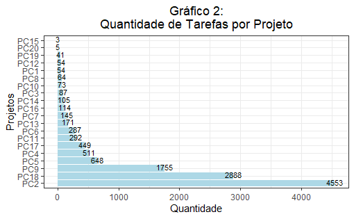

Além do tipo de categoria para cada tarefa, elas são divididas também por Projetos, que no conjunto de dados, constam 20 projetos de desenvolvimento, sendo o Projeto 15 com o menor número de tarefas, 3 no total, e o Projeto 2 com o maior número de tarefas, com 4553. É curioso perceber que só 3 projetos possuem mais de 1000 tarefas executadas.

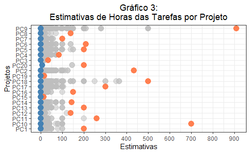

De acordo com o Gráfico 3, é possível verificar as estimativas de horas para o desenvolvimento das tarefas dos projetos. Com a visualização, o Projeto 9 possui a tarefa de maior estimativa, ultrapassando as 900 horas, seguido do Projeto 10 com uma tarefa em torno de 700 horas. Com relação a distribuição das estimativas, na maioria dos projetos percebe-se uma grande concentração até as 100 horas, enquanto o mínimo de horas para as tarefas, ficam entre 0 e 1 hora, apenas com o Projeto 20 se destacando fora desta faixa de valores, sendo de 7 horas o menor valor de uma tarefa.

## Distribuição de Valores

Considerando que o erro em uma estimativa é a diferença entre a estimativa e o tempo que a tarefa de fato tomou e o erro absoluto é o módulo do erro. Pode-se fazer duas perguntas:

**1- Como é a distribuição do erro nas estimativas de diferentes subcategorias de tarefas? Se quiser, use também as categorias nos dados.**

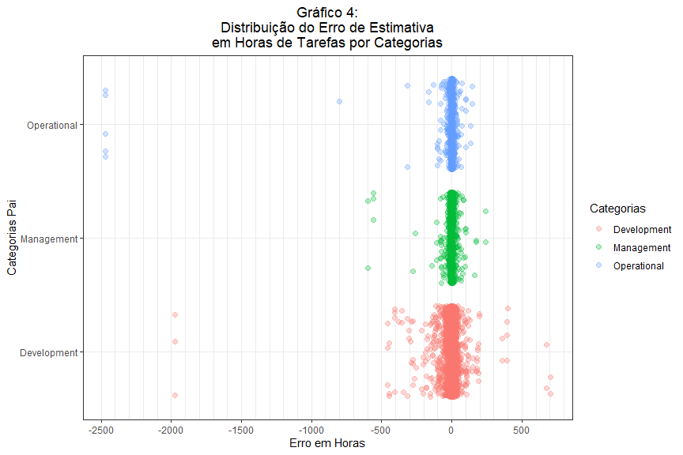

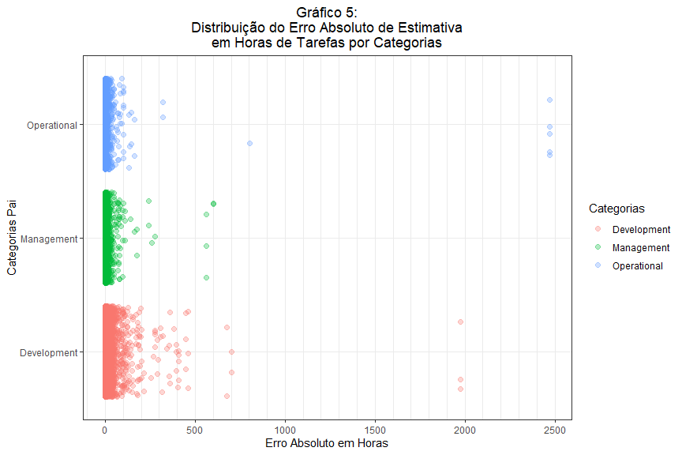

Comparando a distribuição dos erros separados por Categorias das tarefas no Gráfico 4, da pra perceber uma quantidade maior de diferença entre -50 e 50 horas nas categorias Operational e Management, enquanto na categoria Development, a faixa de valores da distribuição pode ser compreendida entre -100 e 100. Na categoria Development, ocorre um grande número de valores de -100 até -500 também em relação às duas outras categorias.

Referindo-se a Outliers, a categoria Operational apresenta os maiores valores, com 5 tarefas na faixa de -2500 horas de erro, enquanto a categoria Development apresenta 3 tarefas em torno de -2000 horas de erro. Já a categoria Management apresenta outliers não tão distantes da concentração das demais tarefas, com cerca de 5 tarefas entre -600 e -550 horas de erro.

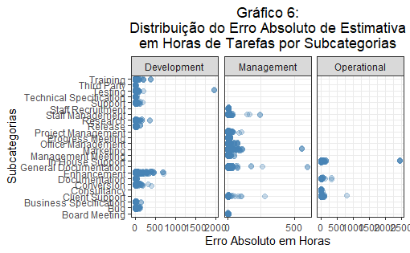

Num cenário dividindo os erros por Subcategorias das tarefas, é possível definir quais subcategorias possuem maior variância de erros, o que leva em consideração também a quantidade de tarefas para cada uma.

Analisando o Gráfico 6 percebemos melhor a distribuição do Erro Absoluto de 0 a 600 na categoria Management, sendo as tarefas de General Documentation e Marketing as de maiores erros respectivamente, com uma maior distribuição erros das tarefas nas subcategorias de Marketing e Office Management. Já se tratando de maior concentração de erros, podemos levar em conta as tarefas de Staff Management, Project Management e General Documentation.

Na categoria Operational, fica mais evidente a pouca quantidade de tarefas em relação às demais categorias, com tarefas existentes em apenas 4 subcategorias:

- In House Support, obtendo os maiores valores de outliers de erro;
- Documentation, com concentração entre 0 e 125 horas de erro, e poucas tarefas entre 125 e 375;
- Consultancy, tendo a maior concentração de erro, entre 0 e 125 horas;
- Client Support, concetração semelhante com as tarefas In House Support, com um único outlier entre 750 e 1000.

**2- Como se comparam as distribuições de tempo (real) das tarefas entre os diferentes times? Há times com tarefas consideravelmente maiores?**

Os times a serem considerados para esta questão são os Projetos, ou seja, desenvolvedores que trabalharam em tarefas pertencentes a um determinado projeto, formam um time, independente se um desenvolvedor irá participar de 2 ou mais projetos.

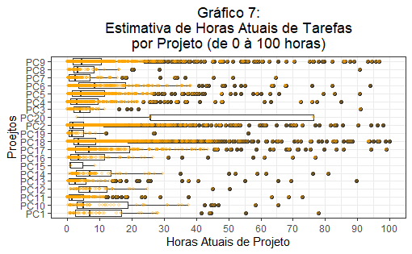

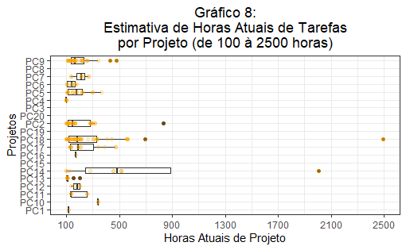

Como forma de melhorar a visualização das horas gastar nas tarefas de acordo com os projetos, foram construídos dois gráficos, sendo o Gráfico 7 com tarefas de até 100 horas gastas e o Gráfico 8 com tarefas de mais de 100 horas, ambos construídos utilizando boxplots como forma de visualização para os 20 projetos existentes.

De acordo com o Gráfico 7, é possível perceber que 50% (interquartil) das tarefas dos projetos estão entre 0 e 20 horas, sendo o Projeto 20 o único em que o interquartil se encontra acima das 20 horas, porém, este Projeto possui apenas 5 tarefas, o que “enviesa” de certa forma a interpretação da visualização do boxplot do mesmo. Os Projetos 2, 18 e 9 possuem mais outliers, com tarefas que se compreendem até próximo o valor de 100 horas, o que pode induzir como os 3 projetos que possuem tarefas com mais horas trabalhadas com relação aos demais.

Analisando o Gráfico 8, já percebe-se que os Projetos 3, 8, 15, 19 e 20 não possuem tarefas que precisaram de mais de 100 horas de trabalho. Os demais Projetos, possuem seu interquartil de Tarefas entre 100 e 500 horas de trabalho, sendo o Projeto 14 com um interquartil entre 250 e 900 horas, visto o número baixo de tarefas analisadas.